# Analyse globale des SNP

Samuel BARRETO

# Lecture des données et nettoyage

Il faut dans un premier temps lire les données, les nettoyer et associer à chaque séquence la catégorie de plasmide transformeur.

La table des identifiants est faite par le script python.

```r
library(dplyr)
library(ggplot2)
library(readr)
library(viridis)
library(purrr)
library(ggthemes)

theme_set(theme_bw() + fte_theme())

data_location <- "../../data/snp_call/snp_calling.dat"
id_table_loc <- "../../data/id_table.dat"
```

J’ai relié les données par un `inner_join` sur la base du nom de l’identifiant de la séquence GATC.

```r
snp <- inner_join(
  x = read_delim(file = data_location, delim = " "),
  y = read_delim(file = id_table_loc, delim = " "),
  by=c("read_name" = "id")) %>%
  select(
    -match,
    -subject_name,
    -index_of_subject,
    read = read_name,
    refb = s_base,
    readb = q_base,
    -s_qual,
    base_q = q_qual,
    refp = offset_on_subject,
    readp = offset_on_read,
    -length_of_subject,
    -length_of_snp,
    readfp = start_match_of_read,
    readlp = end_match_of_read,
    dir = match_direction) %>%
  mutate(name = gsub("-1073bis", "", name))
```

J’ai déterminé les positions des SNP qui nous intéressent dans les deux variables suivantes .

Le code suivant aurait pu inclure les néomutations. Mais à priori, il n’y en a pas.

```r
snppos_sw <- filter(snp, mutant == "sw") %>%
  select(refp) %>%
  distinct() %>%
  unlist() %>%
  as.vector()
snppos_ws <- filter(snp, mutant == "ws") %>%
  select(refp) %>%
  distinct() %>%
  unlist() %>%
  as.vector()
```

# Observations générales

## Nombres de reads par transformation

```r
snp %>%
  group_by(read, mutant) %>%
  summarise(count = n()) %>%
  group_by(mutant) %>%
  summarise(count = n()) %>%
  knitr::kable(col.names = c("Transformant", "Nombre de read"), align = "c")
```

| Transformant | Nombre de read |
| --- | --- |
| sw | 74 |
| ws | 79 |

## Nombre de SNP par transformation

```r
snp %>%
  group_by(mutant) %>%
  summarise(count = n()) %>%
  knitr::kable(col.names = c("Transformant", "Nombre de SNP"), align = "c")
```

| Transformant | Nombre de SNP |
| --- | --- |
| sw | 856 |
| ws | 1018 |

## Distribution du nombre de SNP

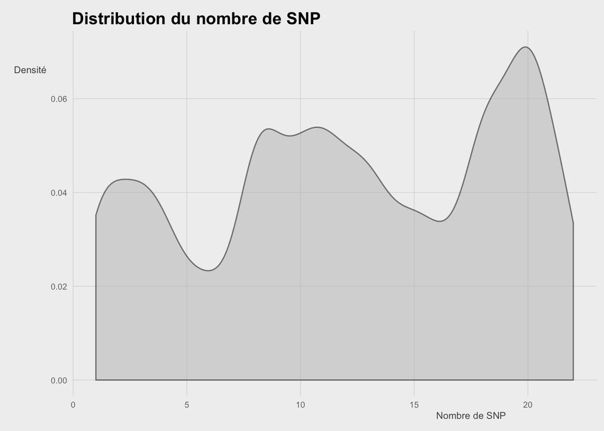

```r
snp %>%
  group_by(read, mutant) %>%
  summarise(count = n()) %>%
  ggplot(aes(x = count)) +
  geom_density(adjust = 0.4, fill = "gray", alpha = 0.5) +
  labs(x = "Nombre de SNP",
       y = "Densité",
       title = "Distribution du nombre de SNP" )
```

## Distribution de la qualité des SNP

J’ai regardé globalement la distribution de la qualité des SNPs.

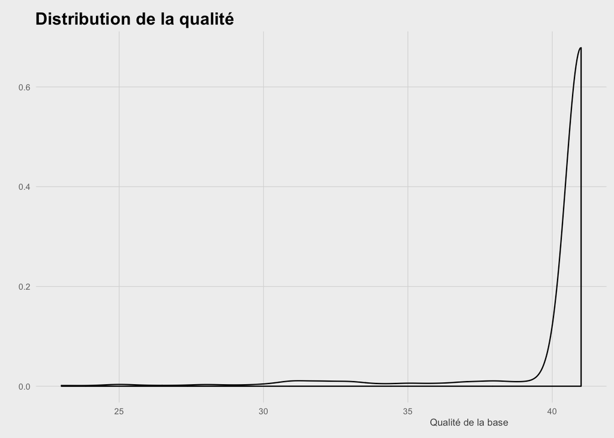

```r
qplot(data = snp, base_q, geom = "density",
      xlab = "Qualité de la base", ylab = "",
      main = "Distribution de la qualité")
```

Si on regarde par globalement comment évolue la qualité des SNPs par séquence :

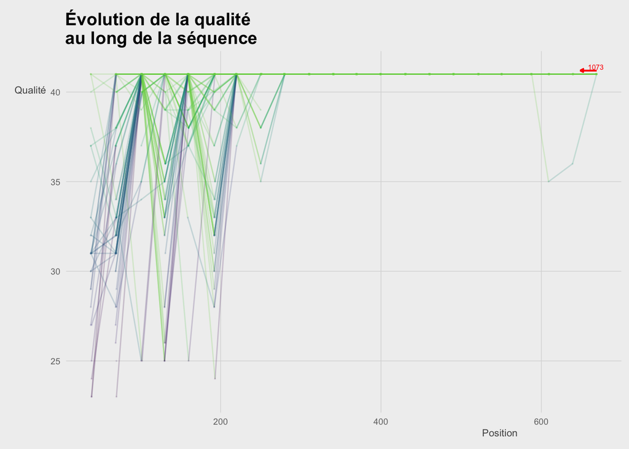

```r
snp %>%
  ggplot(aes(x = refp, y = base_q, color = base_q)) +
  geom_line(aes(group = read), alpha = 1/5) +
  geom_point(alpha = 1/10, size = 1/10) +
  scale_color_viridis(begin = 0, end = 0.8) +
  geom_segment(aes(x = max(refp), xend = max(refp) - 20, y = 41.2, yend = 41.2),
               arrow = arrow(length = unit(0.1, "cm")),
               color = "red") +
  annotate("text", x = 668, y = 41.4, label = "1073", size = 2, color = "red") +
  labs(x = "Position", y = "Qualité",
       title = "Évolution de la qualité\nau long de la séquence")
```

Si on regarde cette qualité par séquence :

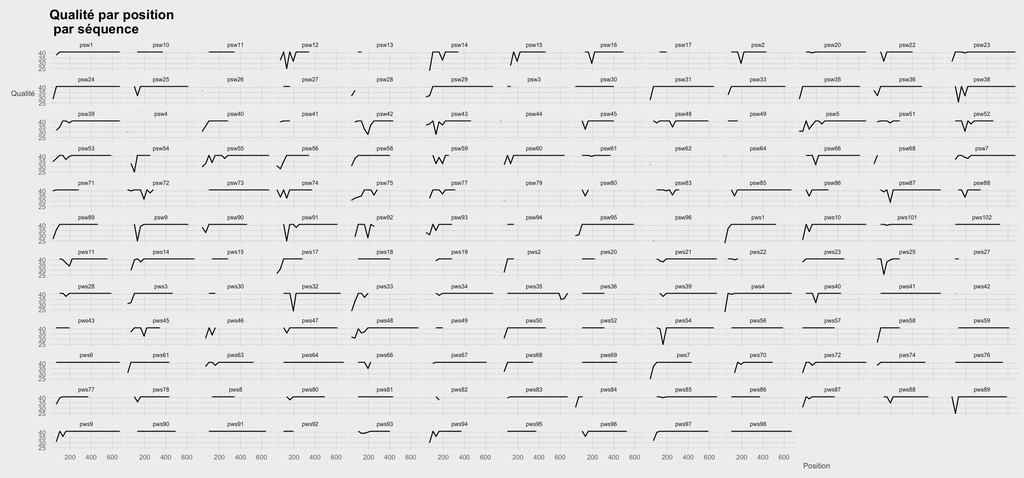

```r
snp %>%
  ggplot(aes(x = refp, y = base_q)) +
  geom_point(alpha = 1/5, size = 0.1) +
  geom_line(alpha = 1) +
  facet_wrap( ~ name) +
  theme(strip.background = element_blank(),
        strip.text = element_text(size= 6),
        axis.text = element_text(size = 5),
        panel.margin = unit(0.1, "lines")) +
  labs(x = "Position", y = "Qualité", title = "Qualité par position\n par séquence")
```

J’ai voulu regarder globalement la distribution des SNP sur les séquences.

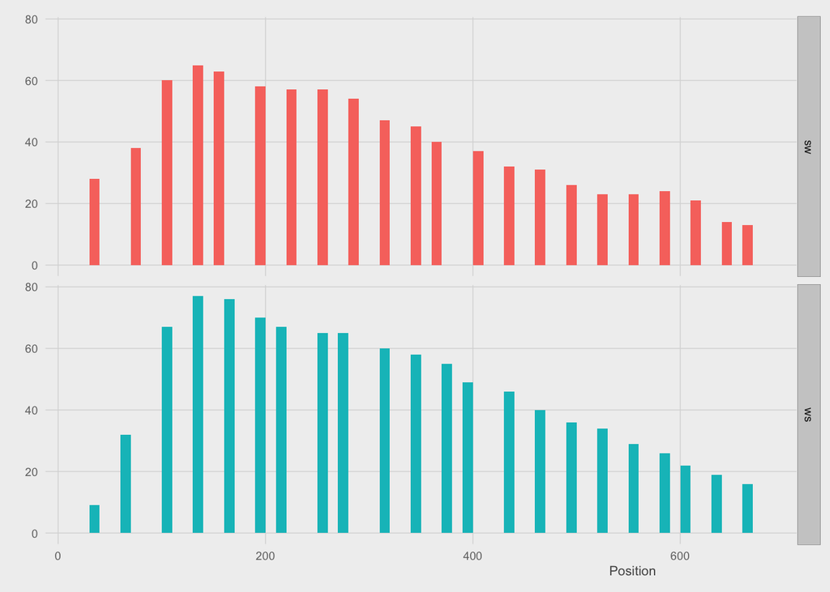

La distribution des SNP en fréquence

```r
snp %>%
  ggplot(aes(x = refp, fill = mutant )) +
  geom_histogram(binwidth = 10) +
  facet_grid(mutant~.) +
  labs(x = "Position", y = "")
```

La distribution des SNP en densité

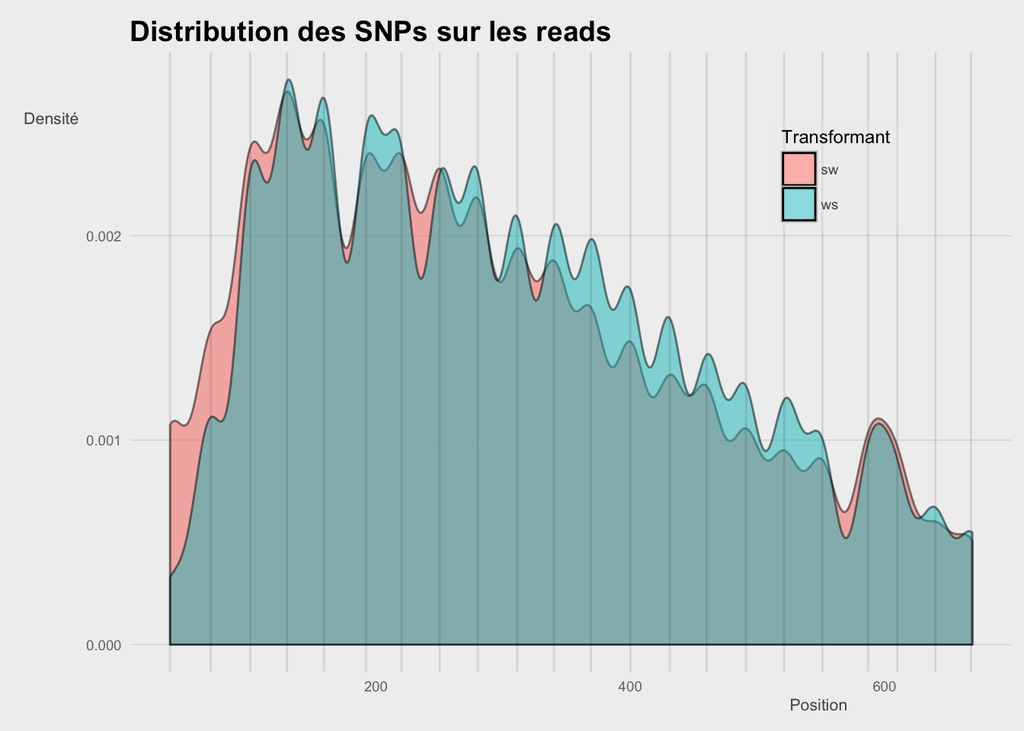

```r
snp %>%
  ggplot(aes(x = refp, fill = mutant )) +
  geom_density(aes(group = mutant), adjust = 1/3, alpha = 1/2) +
  geom_vline(xintercept = snppos_sw, alpha = 0.1) +
  labs(x = "Position",
       y = "Densité",
       title = "Distribution des SNPs sur les reads",
       fill = "Transformant") +
  theme(panel.grid.major.x = element_blank(),
        legend.position = c(0.8, 0.8))
```

## Définition des transitions

J’ai défini une fonction qui permet de déterminer le type de mutation, de strong à weak (`sw`), de weak à strong (`ws`) ou autre.

```r
## #' une fonction qui définit le type de transition, de la référence
## #' à la séquence observée.
find_transition <- function(ref, base) {
  stopifnot(typeof(ref) == "character", typeof(base) == "character")

  is_W <- function(base) ifelse(base == "A" || base == "T", TRUE, FALSE)
  is_S <- function(base) ifelse(base == "C" || base == "G", TRUE, FALSE)

  if      (is_W(ref) & is_S(base)) "ws"
  else if (is_S(ref) & is_W(base)) "sw"
  else if (is_S(ref) & is_S(base)) "ss"
  else if (is_W(ref) & is_W(base)) "ww"
  else stop("Base ", ref, " or base ", base, " is not a DNA base.",
            call. = FALSE)
}
```

J’ai d’abord regardé si on avait des SNPs improbables, *ie* des mutations de W à W (`ww`) ou de S à S (`ss`).

```r
snp %>%
  rowwise() %>%
  mutate(trans = find_transition(refb, readb)) %>%
  filter(trans %in% c("ss", "ww")) %>%
  print()
```

```
## Source: local data frame [0 x 12]
## Groups: <by row>
##
## Variables not shown: read (int), refb (chr), readb (chr), base_q (int),
##   refp (int), readp (int), readfp (int), readlp (int), dir (int), name
##   (chr), mutant (chr), trans (chr)
```

Il n’y en a pas. Plutôt une bonne nouvelle !

## Distribution par type de mutation

J’ai voulu voir si les mutations S->W et les mutations W->S étaient réparties différemment sur les séquences.

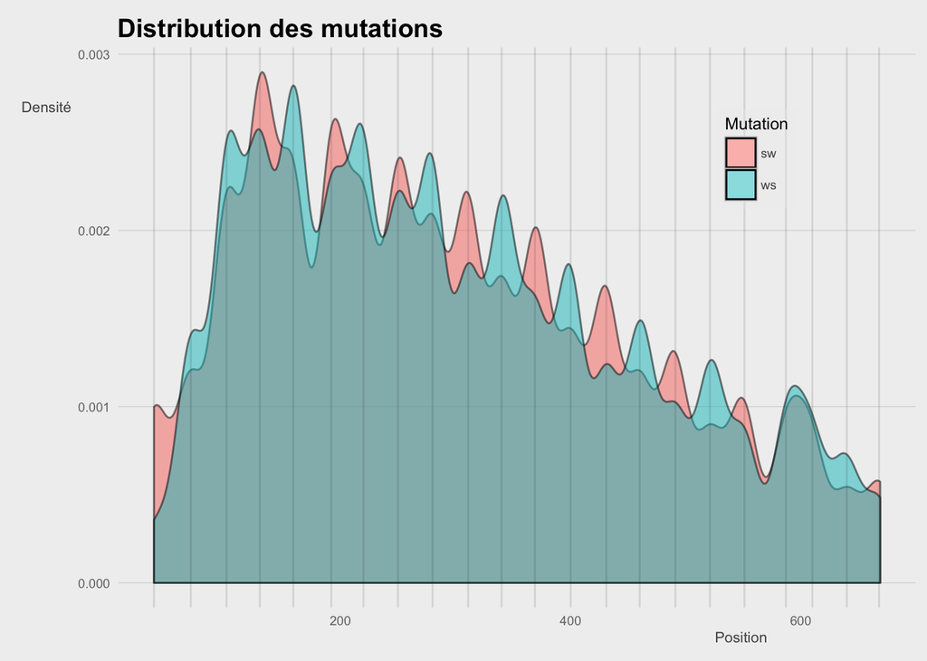

```r
snp %>%
  rowwise() %>%
  mutate(trans = find_transition(refb, readb)) %>%
  ggplot(aes(x = refp, fill = trans)) +
  geom_density(adjust = 1/3, alpha = 1/2) +
  geom_vline(xintercept = snppos_sw, alpha = 0.1) +
  theme(panel.grid.major.x = element_blank()) +
  labs(x = "Position",
       y = "Densité",
       fill = "Mutation",
       title = "Distribution des mutations") +
  legend_position(0.8, 0.8)
```

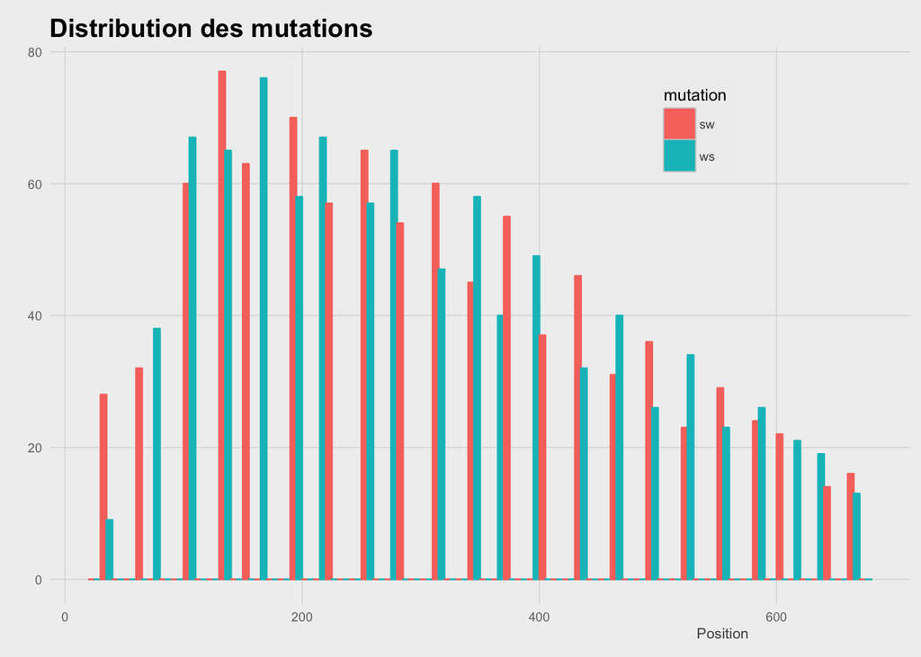

```r
snp %>%
  rowwise() %>%
  mutate(trans = find_transition(refb, readb)) %>%
  ggplot(aes(x = refp )) +
  geom_histogram(aes(fill = trans, color = trans), binwidth = 10,
                 position = "dodge" ) +
  labs(x = "Position", y = "",
       title = "Distribution des mutations",
       fill = "mutation",
       color = "mutation") +
  legend_position(0.75, 0.85)
```

# Trace de conversion

## Distribution de la longueur

J’ai ensuite regardé comment étaient réparties les longeurs de trace de conversion sur les séquences.

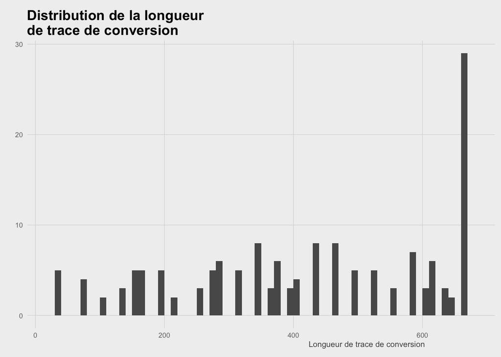

```r
snp %>%
  group_by(read) %>%
  summarise(max = max(refp)) %>%
  ggplot(aes(x = max)) +
  geom_histogram(binwidth = 10) +
  labs(x = "Longueur de trace de conversion",
       y = "",
       title = "Distribution de la longueur\nde trace de conversion" )
```

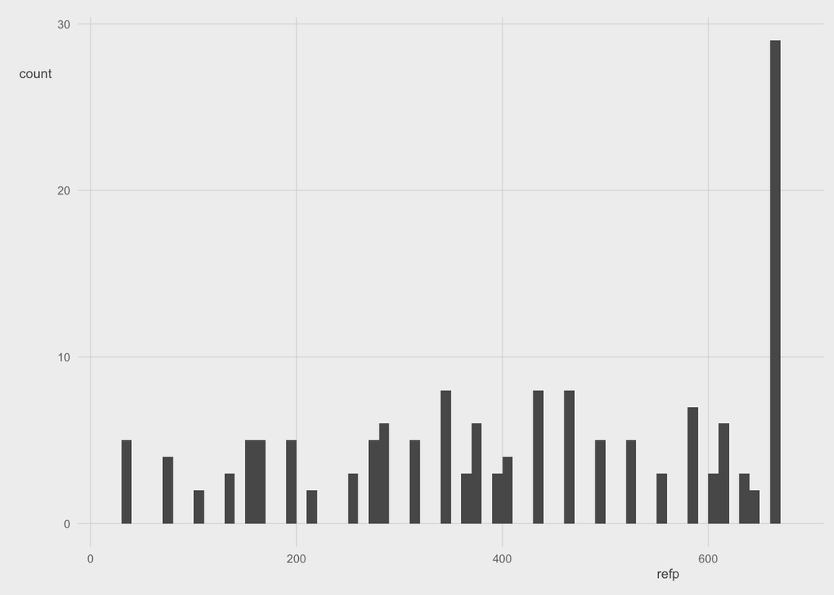

```r
snp %>%
  group_by(read, mutant) %>%
  summarise(max = max(refp)) %>%
  inner_join(x = snp, y = .) %>%
  filter(refp == max) %>%
  ggplot(aes(x = refp)) +
  geom_histogram(binwidth = 10)
```

À première vue, le dernier SNP est souvent dans la partie 3’ du gène. Cette distribution là n’est pas celle qu’on avait avec les séquences W et S.

J’ai donc voulu voir s’il y avait une différence de longueur de trace de conversion entre les séquences de SW et les séquences WS, dans un premier temps en fréquence, puis en densité.

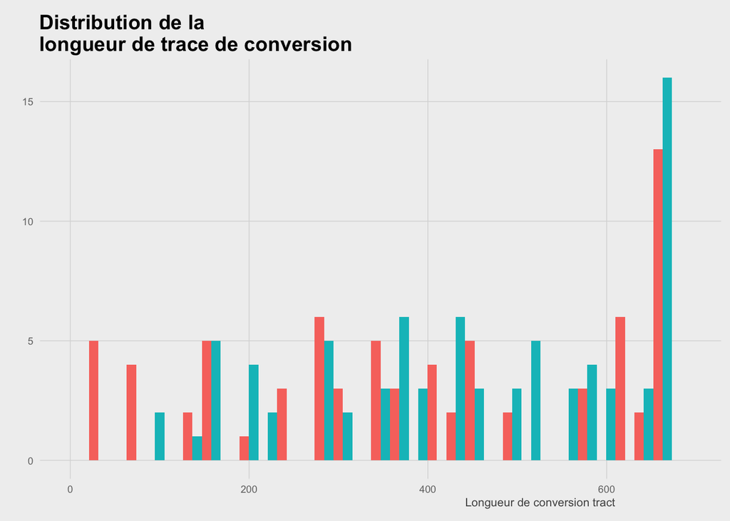

```r
snp %>%
  group_by(read, mutant) %>%
  summarise(max = max(refp)) %>%
  ggplot(aes(x = max)) +
  geom_histogram(aes(fill = mutant), position = "dodge") +
  labs(fill = "Transformant", x = "Longueur de conversion tract", y = "") +
  ggtitle( "Distribution de la\nlongueur de trace de conversion")
```

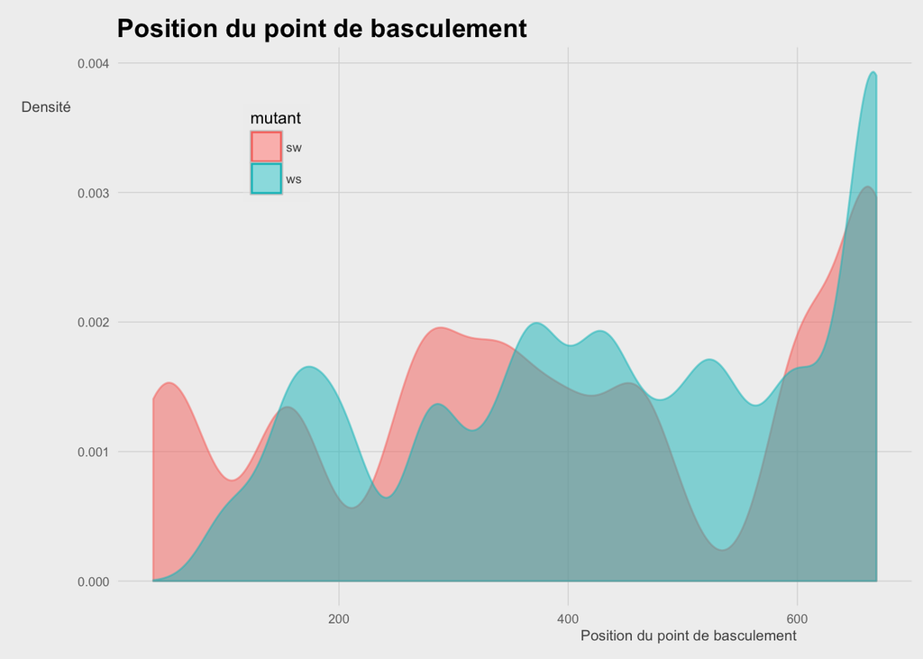

```r
snp %>%
  group_by(read, mutant) %>%
  summarise(max = max(refp)) %>%
  ggplot(aes(x = max, fill = mutant, color = mutant)) +
  geom_density(adjust = 1/3, alpha = 0.5) +
  labs(y = "Densité", x = "Position du point de basculement",
       title = "Position du point de basculement") +
  theme(legend.position = c(0.2, 0.81))
```

J’ai voulu voir si le point de switch était plus souvent à un SNP strong que weak.

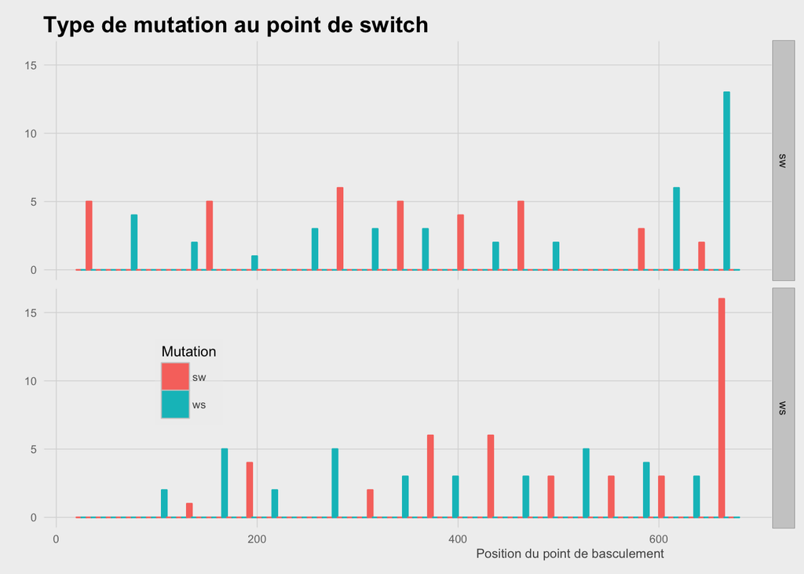

```r
snp %>%
  group_by(read, mutant) %>%
  summarise(max = max(refp)) %>%
  inner_join(x = snp, y = .) %>%
  filter(refp == max) %>%
  rowwise() %>%
  mutate(trans = find_transition(refb, readb)) %>%
  ggplot(aes(x = max)) +
  geom_histogram(aes(fill = trans, color = trans), position = "dodge", binwidth = 10) +
  legend_position(0.2, 0.3) +
  labs(x = "Position du point de basculement",
       y = "",
       fill = "Mutation",
       color = "Mutation",
       title = "Type de mutation au point de switch") +
  facet_grid( mutant ~ .)
```

# En(-)quête de néo-mutations…

J’ai voulu voir si on retrouvait les néomutations du séquençage précédent dans la trace de conversion. Le problème c’est que cette fois la distribution du nombre de SNP à une position donnée ne permet pas de discriminer facilement les positions de SNP calibré avec les néo-mutations. J’ai donc décidé de ne regarder que les positions où le nombre de SNP est de 1, en supposant qu’elles incluent les positions de néo-mutation.

```r
snp %>%
  group_by(refp) %>%
  summarise(count = n()) %>%
  filter(count == 1) %>%
  print()
```

```
## Source: local data frame [0 x 2]
##
## Variables not shown: refp (int), count (int)
```

En clair, il n’y a pas de position où on ne retrouve qu’un SNP. Donc si néo-mutation il y a, elle occasionne dans au moins deux séquences différentes un même SNP. Ce qui est peu probable.

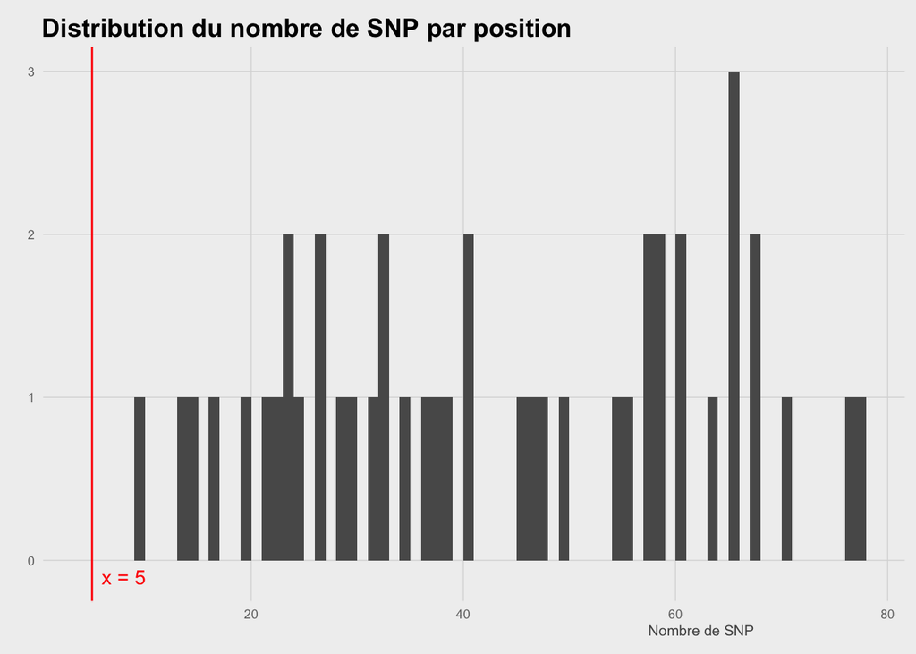

```r
snp %>%
  group_by(refp) %>%
  summarise(count = n()) %>%
  ## (X) filter(count < 5) %>%
  ggplot(aes(x = count)) +
  geom_histogram(binwidth = 1) +
  geom_vline(xintercept = 5, color = "red") +
  annotate("text", label = "x = 5", color = "red", x = 8, y = -0.1) +
  labs(x = "Nombre de SNP",
       y = "",
       title = "Distribution du nombre de SNP par position")
```

En fait aucune position de SNP calibrée ne génère moins de 5 mutations. On peut donc en conclure qu’il n’y a pas de néomutations dans cette manip.

```r
## (X) #' [ ] échantillonne autant de positions aléatoirement dans les
## (X) #' groupes sw et ws. $856$ est le nombre de positions maximum pour
## (X) #' équilibrer le plan.
## (X) #'
## (X) #'
## (X) #+ wip, echo=FALSE

## (X)                                         # WIP
## (X) snp %>%
## (X)   rowwise() %>%
## (X)   mutate(trans = find_transition(refb, readb)) %>%
## (X)   ungroup() %>%
## (X)   group_by(mutant) %>%
## (X)   ## (X) filter(base_q > 40 ) %>%
## (X)   sample_n(856, FALSE) %>%              # échantillonne autant de positions dans les deux groupes.
## (X)   ggplot(aes(x = refp, fill = trans )) +
## (X)   geom_histogram(position = "dodge", binwidth = 10) +
## (X)   ## geom_density(aes(group = mutant), adjust = 1/5, alpha = 1/2) +
## (X)   legend_position(0.8, 0.8)

## (X) sapply(1:10, function(i) snp %>% group_by(mutant) %>% sample_n(856) )

## (X)                                         # END WIP

## (X) ## (X) test_snp <- apply(
## (X) ## (X)   sapply(1:3, function(i) snp %>% group_by(mutant) %>% sample_n(856)),
## (X) ## (X)   2, as_data_frame
## (X) ## (X) )

## (X) ## (X) test_snp[[1]]

## (X) snp %>%
## (X)   group_by(read, mutant) %>%
## (X)   summarise(max = max(refp)) %>%
## (X)   inner_join(x = snp, y = .) %>%
## (X)   filter(refp == max) %>%
## (X)   rowwise() %>%
## (X)   mutate(trans = find_transition(refb, readb)) %>%
## (X)   ggplot(aes(x = max)) +
## (X)   geom_histogram(aes(fill = trans, color = trans), position = "dodge", binwidth = 10) +
## (X)   ## legend_position(0.2, 0.5) +
## (X)   labs(x = "Position du point de basculement",
## (X)        y = "",
## (X)        fill = "Mutation",
## (X)        color = "Mutation",
## (X)        title = "Type de mutation au point de switch") +
## (X)   facet_grid( mutant )
```